# Análise de covariância

Denis

2021-04-29

Acompanhamento da aula da Professora Fernanda, publicada no dia 14/7/20 no Youtube:

https://www.youtube.com/watch?v=EyqkuCNgj2Y&ab_channel=FernandaPeres

```r
dados <- data.frame(
  stringsAsFactors = T,
           Sujeito = c(1L,2L,3L,4L,5L,6L,7L,8L,
                       9L,10L,11L,12L,13L,14L,15L,16L,17L,18L,19L,
                       20L,21L,22L,23L,24L,25L,26L,27L,28L,29L,30L),
            Gênero = c("M","F","M","M","F","F",
                       "M","M","M","M","F","F","F","F","F","M","M","M",
                       "F","M","M","F","F","F","M","F","F","M","M",
                       "F"),
    Grau_Instrução = c("Superior","Superior",
                       "Superior","Ens Fundamental","Ensino Médio","Superior",
                       "Ens Fundamental","Superior","Superior","Ensino Médio",
                       "Superior","Ensino Médio","Ensino Médio","Ensino Médio",
                       "Ensino Médio","Superior","Superior","Superior",
                       "Ensino Médio","Ensino Médio","Ens Fundamental",
                       "Ens Fundamental","Ensino Médio","Superior","Ensino Médio",
                       "Ens Fundamental","Superior","Ens Fundamental","Superior",
                       "Superior"),
          n_Filhos = c(1L,0L,0L,0L,0L,2L,0L,0L,
                       1L,2L,0L,3L,0L,0L,1L,1L,0L,0L,2L,2L,2L,0L,
                       0L,2L,4L,1L,1L,0L,0L,1L),
             Idade = c(31L,25L,33L,20L,23L,37L,
                       38L,37L,34L,40L,41L,46L,26L,41L,43L,27L,26L,42L,
                       43L,30L,35L,33L,30L,32L,29L,40L,36L,34L,31L,
                       35L),
           Salário = c(8.2,5.3,9.4,2.9,3.7,4.4,
                       4.7,5.4,5.8,3.2,6,6.9,2,3.4,3.7,4.2,6.4,11.6,
                       8.6,5.5,6.8,4.1,4.6,6.6,7.3,7.3,8.3,3.8,6.2,8)
)
```

```r
summary(dados)
```

```
##     Sujeito      Gênero         Grau_Instrução    n_Filhos          Idade
##  Min.   : 1.00   F:15   Ens Fundamental: 6     Min.   :0.0000   Min.   :20.00
##  1st Qu.: 8.25   M:15   Ensino Médio   :10     1st Qu.:0.0000   1st Qu.:30.00
##  Median :15.50          Superior       :14     Median :0.5000   Median :34.00
##  Mean   :15.50                                 Mean   :0.8667   Mean   :33.93
##  3rd Qu.:22.75                                 3rd Qu.:1.7500   3rd Qu.:39.50
##  Max.   :30.00                                 Max.   :4.0000   Max.   :46.00
##     Salário
##  Min.   : 2.000
##  1st Qu.: 4.125
##  Median : 5.650
##  Mean   : 5.810
##  3rd Qu.: 7.200
##  Max.   :11.600
```

Neste exemplo, queremos analisar se o grau de instrução desses indivíduos tem efeito sobre os salários, controlando esse efeito pela idade.

Mas, primeiro, vamos analisar os pressupostos de uma análise de covariância. Neste banco temos como variável dependente a variável *Salário*, variável independente *Grau de instrução* e como covariável *idade*:

1 - vamos verificar se há efeito da variável independente sobre a covariável:

iniciamos com nossa hipótese nula $H_0$: não há efeito da variável independente na covariável (p>0,05).

```r
summary(aov(Idade ~ Grau_Instrução, data = dados))
```

```
##                Df Sum Sq Mean Sq F value Pr(>F)
## Grau_Instrução  2   20.4   10.21   0.227  0.799
## Residuals      27 1215.4   45.02
```

Dessa forma, temos evidência para não rejeitar $H_0$ e constatar que não há efeito do grau de instrução na idade.

2 - verificar se a relação entre a covariável e a variável dependente é linear (VD ~ cov)

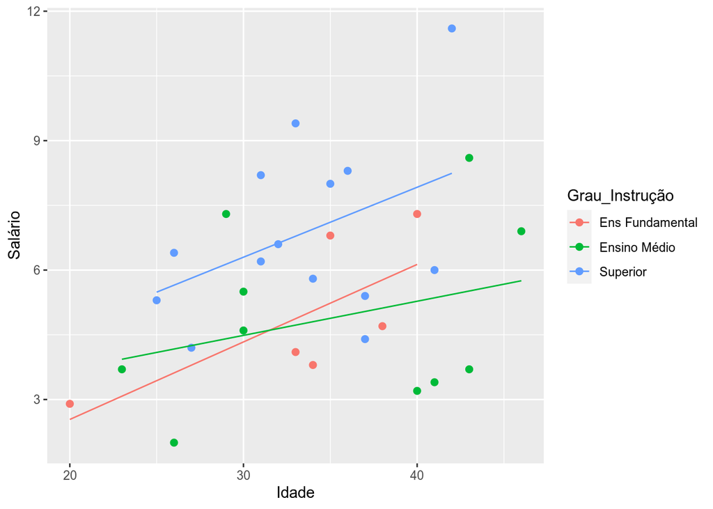

```r
ggplot2::ggplot(dados, ggplot2::aes(x = Idade, y = Salário, group = Grau_Instrução, color = Grau_Instrução))+
  ggplot2::geom_point(size = 2) +
  ggplot2::geom_smooth(method = "lm", se = F, size = .5)
```

3 - verificar se o efeito da covariável e o mesmo para todos os níveis da variável independente (VD ~ VI * cov). Vamos comparar as inclinações das retas para cada grupo da VI. Ou seja, se houver homogeineidade nos parâmetros da regressão, observaremos retas com inclinações parecidas.

```r
summary(aov(Salário ~ Grau_Instrução*Idade, dados))
```

```
##                      Df Sum Sq Mean Sq F value Pr(>F)
## Grau_Instrução        2  28.01  14.005   3.779 0.0374 *
## Idade                 1  18.47  18.470   4.984 0.0352 *
## Grau_Instrução:Idade  2   2.52   1.261   0.340 0.7150
## Residuals            24  88.95   3.706
## ---
## Signif. codes:  0 '***' 0.001 '**' 0.01 '*' 0.05 '.' 0.1 ' ' 1
```

```r
car::Anova(aov(Salário ~ Grau_Instrução*Idade, dados), Type = "III")
```

```
## Anova Table (Type II tests)
##
## Response: Salário
##                      Sum Sq Df F value  Pr(>F)
## Grau_Instrução       31.968  2  4.3130 0.02511 *
## Idade                18.470  1  4.9836 0.03518 *
## Grau_Instrução:Idade  2.522  2  0.3402 0.71501
## Residuals            88.946 24
## ---
## Signif. codes:  0 '***' 0.001 '**' 0.01 '*' 0.05 '.' 0.1 ' ' 1
```

É necessário que a interação entre grau de instrução e idade não seja significativo. Neste teste, vamos ter a $H_0$ de que há homogeneidade dos parâmetros da regressão (p > 0.05).

4 - Verificar se há homogeneidade de variâncias (VD ~ VI)

```r
car::leveneTest(Salário ~ Grau_Instrução, center = mean,  dados)
```

```
## Levene's Test for Homogeneity of Variance (center = mean)
##       Df F value Pr(>F)
## group  2  0.1854 0.8318
##       27
```

Temos que a $H_0$ é que as variâncias são homogêneas (P>0.05).

5 - Ajustar o modelo de ANCOVA (VD ~ cov + VI)

```r
car::Anova(aov(Salário ~ Idade + Grau_Instrução, data = dados), type = "III")
```

```
## Anova Table (Type III tests)
##
## Response: Salário
##                Sum Sq Df F value  Pr(>F)
## (Intercept)     0.629  1  0.1787 0.67596
## Idade          18.470  1  5.2501 0.03030 *
## Grau_Instrução 31.968  2  4.5436 0.02031 *
## Residuals      91.467 26
## ---
## Signif. codes:  0 '***' 0.001 '**' 0.01 '*' 0.05 '.' 0.1 ' ' 1
```

Temos que a $H_0$ é que não há efeito (p >.05). Neste caso, temos o efeito do grau de instrução contralado pela idade.

6 - Verificar a normalidade dos resíduos

```r
shapiro.test(aov(Salário ~ Idade + Grau_Instrução, data = dados)$residuals)
```

```
##
##  Shapiro-Wilk normality test
##
## data:  aov(Salário ~ Idade + Grau_Instrução, data = dados)$residuals
## W = 0.96498, p-value = 0.4122
```

No teste de shapiro, temos que a $H_0$ define a distribuição do dados como normal (p >0.05).

7 - Verificar se há homocedasticidade e outliers:

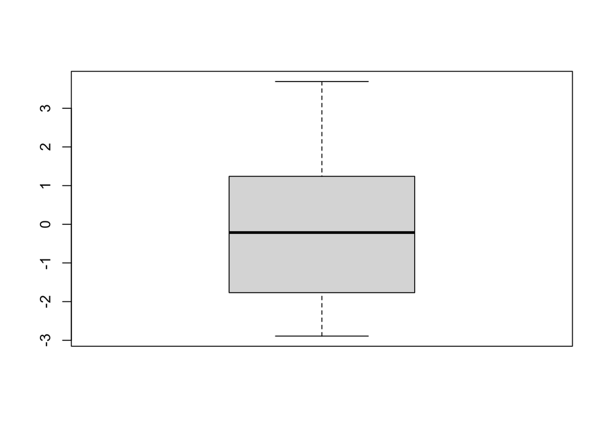

```r
boxplot(aov(Salário ~ Idade + Grau_Instrução, data = dados)$residuals)
```

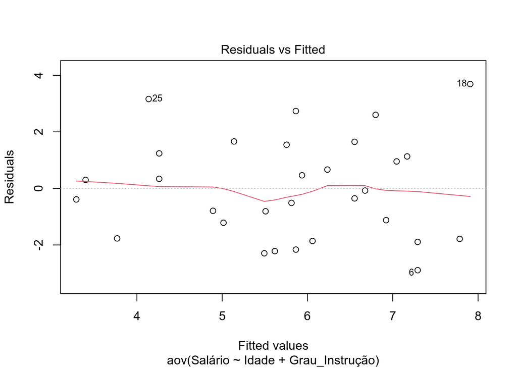

```r
plot(aov(Salário ~ Idade + Grau_Instrução, data = dados), which = 1)
```

Neste gráfico vemos a distribuição dos resíduos. Se houver homocedasticidade, veremos um padrão disperso (talvez mais retangular) dos resíduos. Quando ao contrario, veríamos um funil.